# ErythroCite database

Electronic Supplementary Material

Félix P. Leiva

latest update: 09 February 2026

# Welcome

This is an R Markdown document that summarises the main figures and data associated with the information present in the **ErythroCite** database. This database uses a systematic map to search for information on the cell size of fish blood cells.

# Summary

# Citation

When using the data and/or code associated with this project, they msut be cited as follows:

- Leiva, F. P., Molina-Venegas, R., Alter, K., Freire, C.A., Hendriks A. J., Hermaniuk, A., Serre-Fredj, L., Shokri, M., Czarnoleski, M., & Mark, F. C. (2026). ErythroCite: a database on red blood cell size of fishes. Scientific Data.
- Leiva, F. P., Molina-Venegas, R., Alter, K., Freire, C. A., Hendriks A. J., Hermaniuk, A., Serre-Fredj, L., Shokri, M., Czarnoleski, M., & Mark, F. C. (2026). ErythroCite: a database on red blood cell size of fishes. Zenodo. https://doi.org/10.5281/zenodo.18543381.

# Contact

This script is authored by **Félix P. Leiva**. For any questions related to this resource, please contact me at the email address: **felixpleiva@gmail.com**.

# Disclaimer

This code routine may contain typographical errors, specific lines of code, or comments in Spanish (my native language). I apologise for any inconvenience this might cause in understanding the code.

I will update the GitHub repository with any identified errors when appropriate. Therefore, I strongly recommend users to check the repository where the data are stored: https://github.com/felixpleiva/ErythroCite. This ensures access to the most current version of the code and data.

Should you encounter any errors in the code or data, please let me know via email.

Gracias!

# Licence

This repository is provided by the author under the licence [Attribution-NonCommercial-NoDerivatives 4.0 International](https://creativecommons.org/licenses/by-nc-nd/4.0/deed.en).

# Clean working space

```r
rm(list = ls())
```

# Load libraries

```r
library(kableExtra)       # Enhances tables created with 'knitr::kable'
library(DataExplorer)     # Automates exploratory data analysis
library(dplyr)            # Efficient data manipulation
library(ggplot2)          # Data visualisation based on the grammar of graphics
library(RefManageR)       # Manages references and citations
library(ggpubr)           # Creates publication-ready graphics
library(cowplot)          # Arranges and annotates plots
library(tidygeocoder)     # Converts addresses into geographic coordinates
library(rnaturalearth)    # Accesses Natural Earth geographic data
library(ape)              # Analyses phylogenies and evolution
library(ggtree)           # Visualises and annotates phylogenetic trees
library(tibble)           # Alternative to data frames
library(ggthemes)         # Additional themes for 'ggplot2' graphics
library(fishualize)       # Fish-inspired colour palettes
library(sessioninfo)      # Documents session environment for reproducibility
library(details)          # Adds inline or interactive details
library(rfishbase)        # Retrieve taxonomy from FishBase (https://www.fishbase.se)
```

# Download data

**Zenodo**: https://doi.org/10.5281/zenodo.18543381

# Load data

```r
dat <- read.csv("../outputs/cell_size_with_taxonomy.csv")
```

# Load phylogenetic tree

```r
tree<-read.tree("../outputs/Phylogenetic tree for 650 species included in ErythroCite.tre")
```

# Load references

```r
refs <- ReadBib("../outputs/ErythroCite literature.bib")
```

# Data exploration

## Check and reformat variables

```r
str(dat)
```

```
## 'data.frame':    1765 obs. of  45 variables:
##  $ species_reported    : chr  "Abalistes stellatus" "Abramis brama" "Abudefduf marginatus" "Abudefduf saxatilis" ...
##  $ double_checked      : chr  "YES" "YES" "YES" "YES" ...
##  $ database            : chr  "Gregory_2024" "Gregory_2024" "systematic_search_english" "felix" ...
##  $ key                 : chr  "9_gregory" "pdf_not_found_Gulliver_1875" "rayyan-33186100" "16_fpl" ...
##  $ body_mass_gram      : num  NA NA NA NA NA NA NA NA NA NA ...
##  $ sex                 : chr  NA NA NA NA ...
##  $ life_stage          : chr  NA NA NA NA ...
##  $ lat_dec             : num  NA NA 32.4 18.2 18.2 ...
##  $ long_dec            : num  NA NA -64.7 -66.5 -66.5 ...
##  $ location_description: chr  NA NA "near the Bermuda Biological Station, St. George, Bermuda\n" "southwestern and western coasts of Puerto Rico" ...
##  $ sample_size         : int  NA NA 50 NA NA NA NA NA NA NA ...
##  $ number_of_specimens : int  NA NA NA NA NA NA NA NA NA NA ...
##  $ estimate_error_type : chr  NA NA "2SE" NA ...
##  $ cell_length         : num  NA 10.6 NA 10.2 10 10.5 10.5 10 9 9 ...
```

[output cut: 31 more lines]

```r
dat$sex <- as.factor(dat$sex)
dat$life_stage <- as.factor(dat$life_stage)
dat$sample_size <- as.factor(dat$sample_size)
dat$number_of_specimens <- as.factor(dat$number_of_specimens)
```

## Check again

```r
str(dat)
```

```
## 'data.frame':    1765 obs. of  45 variables:
##  $ species_reported    : chr  "Abalistes stellatus" "Abramis brama" "Abudefduf marginatus" "Abudefduf saxatilis" ...
##  $ double_checked      : chr  "YES" "YES" "YES" "YES" ...
##  $ database            : chr  "Gregory_2024" "Gregory_2024" "systematic_search_english" "felix" ...
##  $ key                 : chr  "9_gregory" "pdf_not_found_Gulliver_1875" "rayyan-33186100" "16_fpl" ...
##  $ body_mass_gram      : num  NA NA NA NA NA NA NA NA NA NA ...
##  $ sex                 : Factor w/ 3 levels "both","female",..: NA NA NA NA NA NA NA NA NA NA ...
##  $ life_stage          : Factor w/ 3 levels "adult","fingerlings",..: NA NA NA NA NA NA NA NA NA NA ...
##  $ lat_dec             : num  NA NA 32.4 18.2 18.2 ...
##  $ long_dec            : num  NA NA -64.7 -66.5 -66.5 ...
##  $ location_description: chr  NA NA "near the Bermuda Biological Station, St. George, Bermuda\n" "southwestern and western coasts of Puerto Rico" ...
##  $ sample_size         : Factor w/ 37 levels "1","2","3","4",..: NA NA 22 NA NA NA NA NA NA NA ...
##  $ number_of_specimens : Factor w/ 45 levels "1","2","3","4",..: NA NA NA NA NA NA NA NA NA NA ...
##  $ estimate_error_type : chr  NA NA "2SE" NA ...
##  $ cell_length         : num  NA 10.6 NA 10.2 10 10.5 10.5 10 9 9 ...
```

[output cut: 31 more lines]

```r
head(dat)
```

```
##       species_reported double_checked                  database
## 1  Abalistes stellatus            YES              Gregory_2024
## 2        Abramis brama            YES              Gregory_2024
## 3 Abudefduf marginatus            YES systematic_search_english
## 4  Abudefduf saxatilis            YES                     felix
## 5  Abudefduf saxatilis            YES                     felix
## 6  Abudefduf saxatilis            YES                     felix
##                           key body_mass_gram  sex life_stage  lat_dec  long_dec
## 1                   9_gregory             NA <NA>       <NA>       NA        NA
## 2 pdf_not_found_Gulliver_1875             NA <NA>       <NA>       NA        NA
## 3             rayyan-33186100             NA <NA>       <NA> 32.36700 -64.69760
## 4                      16_fpl             NA <NA>       <NA> 18.22477 -66.48583
## 5                      16_fpl             NA <NA>       <NA> 18.22477 -66.48583
## 6                      16_fpl             NA <NA>       <NA> 18.22477 -66.48583
##                                         location_description sample_size
```

[output cut: 69 more lines]

## Inspection of the data set

Checks following code of Pottier et al. 2021. Sexual (in)equality? A meta-analysis of sex differences in thermal acclimation capacity across ectotherms (also cited in the main text).

```r
kable(summary(dat), "html") %>%
  kable_styling("striped", position = "left") %>%
  scroll_box(width = "100%", height = "500px")
```

|  | species_reported | double_checked | database | key | body_mass_gram | sex | life_stage | lat_dec | long_dec | location_description | sample_size | number_of_specimens | estimate_error_type | cell_length | cell_length_error | cell_width | cell_width_error | cell_area | cell_area_error | cell_volume | cell_volume_error | mcv | mcv_error | nucleus_length | nucleus_length_error | nucleus_width | nucleus_width_error | nucleus_area | nucleus_area_error | … |
| --- | --- | --- | --- | --- | --- | --- | --- | --- | --- | --- | --- | --- | --- | --- | --- | --- | --- | --- | --- | --- | --- | --- | --- | --- | --- | --- | --- | --- | --- | --- |
|  | Length:1765 | Length:1765 | Length:1765 | Length:1765 | Min. : 0.51 | both : 98 | adult : 204 | Min. :-42.39 | Min. :-107.31 | Length:1765 | 30 : 30 | 10 : 24 | Length:1765 | Min. : 5.51 | Min. :0.0090 | Min. : 3.740 | Min. : 0.008 | Min. : 16.22 | Min. : 0.120 | Min. : 41.08 | Min. : 1.438 | Min. : 0.019 | Min. : 0.0014 | Min. : 2.240 | Min. :0.0100 | Min. :1.440 | Min. :0.0200 | Min. : 2.56 | Min. : 0.030 | … |
|  | Class :character | Class :character | Class :character | Class :character | 1st Qu.: 25.68 | female: 47 | fingerlings: 9 | 1st Qu.: 18.22 | 1st Qu.: -66.49 | Class :character | 1 : 25 | 20 : 14 | Class :character | 1st Qu.: 9.50 | 1st Qu.:0.2075 | 1st Qu.: 6.500 | 1st Qu.: 0.220 | 1st Qu.: 58.05 | 1st Qu.: 2.435 | 1st Qu.: 286.00 | 1st Qu.:11.700 | 1st Qu.: 107.025 | 1st Qu.: 2.8162 | 1st Qu.: 4.400 | 1st Qu.:0.2000 | 1st Qu.:3.000 | 1st Qu.:0.1500 | 1st Qu.: 10.84 | 1st Qu.: 0.500 | … |
|  | Mode :character | Mode :character | Mode :character | Mode :character | Median : 78.10 | male : 41 | juvenile : 72 | Median : 18.22 | Median : -66.49 | Mode :character | 20 : 24 | 30 : 14 | Mode :character | Median :10.00 | Median :0.4150 | Median : 7.500 | Median : 0.340 | Median : 70.38 | Median : 4.250 | Median : 579.52 | Median :23.000 | Median : 150.738 | Median : 11.8000 | Median : 5.250 | Median :0.3200 | Median :3.500 | Median :0.2400 | Median : 14.03 | Median : 1.190 | … |
|  | NA | NA | NA | NA | Mean : 1802.84 | NA’s :1579 | NA’s :1480 | Mean : 20.39 | Mean : -10.25 | NA | 50 : 24 | 8 : 12 | NA | Mean :11.15 | Mean :0.6021 | Mean : 7.791 | Mean : 2.692 | Mean : 94.99 | Mean : 6.717 | Mean : 569.99 | Mean :26.096 | Mean : 201.688 | Mean : 19.4054 | Mean : 5.427 | Mean :0.3815 | Mean :3.739 | Mean :0.2902 | Mean : 18.91 | Mean : 1.865 | … |
|  | NA | NA | NA | NA | 3rd Qu.: 203.12 | NA | NA | 3rd Qu.: 30.06 | 3rd Qu.: 76.95 | NA | 5 : 22 | 1 : 11 | NA | 3rd Qu.:11.80 | 3rd Qu.:0.8575 | 3rd Qu.: 8.408 | 3rd Qu.: 0.690 | 3rd Qu.: 89.19 | 3rd Qu.: 6.700 | 3rd Qu.: 693.54 | 3rd Qu.:37.550 | 3rd Qu.: 204.750 | 3rd Qu.: 24.0250 | 3rd Qu.: 6.120 | 3rd Qu.:0.5000 | 3rd Qu.:4.225 | 3rd Qu.:0.4000 | 3rd Qu.: 19.59 | 3rd Qu.: 2.178 | … |
|  | NA | NA | NA | NA | Max. :217271.00 | NA | NA | Max. : 60.95 | Max. : 146.49 | NA | (Other): 91 | (Other): 144 | NA | Max. :44.60 | Max. :2.9530 | Max. :27.000 | Max. :259.334 | Max. :944.70 | Max. :66.600 | Max. :1889.41 | Max. :78.890 | Max. :6940.000 | Max. :293.0000 | Max. :17.500 | Max. :1.4260 | Max. :9.750 | Max. :1.2000 | Max. :157.33 | Max. :14.900 | … |
|  | NA | NA | NA | NA | NA’s :1283 | NA | NA | NA’s :525 | NA’s :525 | NA | NA’s :1549 | NA’s :1546 | NA | NA’s :867 | NA’s :1649 | NA’s :867 | NA’s :1648 | NA’s :1028 | NA’s :1671 | NA’s :1650 | NA’s :1724 | NA’s :1463 | NA’s :1501 | NA’s :1598 | NA’s :1660 | NA’s :1598 | NA’s :1660 | NA’s :1307 | NA’s :1651 | … |

In our analysis, we assessed a range of cellular parameters across multiple studies, including cell size, cell volume, nucleus area, nucleus volume, and mean corpuscular volume. By analyzing and comparing the mean, minimum, and maximum values for each metric, I aim to identify potential outliers and determine whether extreme values are predominantly associated with specific studies.

## Check for extreme values

```r
kable(dat %>%
        group_by(key) %>%
        summarise(mean_cell_area = mean(cell_area), max_cell_area = max(cell_area), min_cell_area = min(cell_area), sd_cell_area = sd(cell_area),
                  mean_cell_volume = mean(cell_volume), max_cell_volume = max(cell_volume), min_cell_volume = min(cell_volume), sd_cell_volume = sd(cell_volume),
                  mean_nucleus_area = mean(nucleus_area), max_nucleus_area = max(nucleus_area), min_nucleus_area = min(nucleus_area), sd_nucleus_area = sd(nucleus_area),
                  mean_nucleus_volume = mean(nucleus_volume), max_nucleus_volume= max(nucleus_volume), min_nucleus_volume = min(nucleus_volume), sd_nucleus_volume = sd(nucleus_volume),
                  mean_mcv = mean(mcv), max_mcv = max(mcv), min_mcv = min(mcv), sd_mcv = sd(mcv),
                  n = n())) %>%
  kable_styling("striped", position = "left") %>%
  scroll_box(width = "100%", height = "500px")
```

| key | mean_cell_area | max_cell_area | min_cell_area | sd_cell_area | mean_cell_volume | max_cell_volume | min_cell_volume | sd_cell_volume | mean_nucleus_area | max_nucleus_area | min_nucleus_area | sd_nucleus_area | mean_nucleus_volume | max_nucleus_volume | min_nucleus_volume | sd_nucleus_volume | mean_mcv | max_mcv | min_mcv | sd_mcv | n |
| --- | --- | --- | --- | --- | --- | --- | --- | --- | --- | --- | --- | --- | --- | --- | --- | --- | --- | --- | --- | --- | --- |
| 11_fpl | 73.20000 | 73.20000 | 73.20000 | NA | NA | NA | NA | NA | 13.300000 | 13.300000 | 13.300000 | NA | NA | NA | NA | NA | 163.80000 | 163.80000 | 163.80000 | NA | 1 |
| 12_fpl | NA | NA | NA | NA | NA | NA | NA | NA | NA | NA | NA | NA | NA | NA | NA | NA | 294.95000 | 529.50000 | 139.70000 | 156.4641013 | 6 |
| 13_gregory | 123.48071 | 303.98000 | 37.70000 | 93.6114967 | NA | NA | NA | NA | 18.417143 | 42.190000 | 7.760000 | 11.094015 | NA | NA | NA | NA | NA | NA | NA | NA | 14 |
| 14_fpl | NA | NA | NA | NA | NA | NA | NA | NA | NA | NA | NA | NA | NA | NA | NA | NA | NA | NA | NA | NA | 1 |
| 15_fpl | NA | NA | NA | NA | NA | NA | NA | NA | NA | NA | NA | NA | NA | NA | NA | NA | NA | NA | NA | NA | 3 |
| 16_fpl | NA | NA | NA | NA | NA | NA | NA | NA | NA | NA | NA | NA | NA | NA | NA | NA | NA | NA | NA | NA | 601 |
| 17_gregory | NA | NA | NA | NA | NA | NA | NA | NA | NA | NA | NA | NA | NA | NA | NA | NA | NA | NA | NA | NA | 12 |
| 18_fpl | NA | NA | NA | NA | NA | NA | NA | NA | NA | NA | NA | NA | NA | NA | NA | NA | NA | NA | NA | NA | 4 |
| 1_fpl | NA | NA | NA | NA | NA | NA | NA | NA | NA | NA | NA | NA | NA | NA | NA | NA | NA | NA | NA | NA | 1 |
| 2_fpl | 75.60000 | 75.60000 | 75.60000 | NA | NA | NA | NA | NA | 12.000000 | 12.000000 | 12.000000 | NA | NA | NA | NA | NA | NA | NA | NA | NA | 1 |
| 3_gregory | NA | NA | NA | NA | NA | NA | NA | NA | NA | NA | NA | NA | NA | NA | NA | NA | NA | NA | NA | NA | 13 |
| 5_fpl | NA | NA | NA | NA | NA | NA | NA | NA | 19.060000 | 21.600000 | 10.500000 | 3.266054 | NA | NA | NA | NA | NA | NA | NA | NA | 10 |
| 6_gregory | NA | NA | NA | NA | NA | NA | NA | NA | NA | NA | NA | NA | NA | NA | NA | NA | NA | NA | NA | NA | 7 |
| 9_gregory | 99.62252 | 639.02000 | 32.34000 | 102.7547647 | NA | NA | NA | NA | 21.001261 | 157.330000 | 5.460000 | 24.679091 | NA | NA | NA | NA | NA | NA | NA | NA | 222 |
| pdf_not_found_Gulliver_1875 | 127.30679 | 944.70000 | 42.80000 | 144.6876504 | NA | NA | NA | NA | NA | NA | NA | NA | NA | NA | NA | NA | NA | NA | NA | NA | 81 |
| pdf_not_found_Kisch_1949a | NA | NA | NA | NA | NA | NA | NA | NA | 19.067273 | 38.170000 | 7.480000 | 11.493088 | NA | NA | NA | NA | NA | NA | NA | NA | 11 |
| pdf_not_found_Kisch_1949b | 123.51750 | 245.26000 | 64.87000 | 83.0318157 | NA | NA | NA | NA | NA | NA | NA | NA | NA | NA | NA | NA | NA | NA | NA | NA | 4 |
| pdf_not_found_Kisch_1951 | 207.45000 | 542.99000 | 75.76000 | 174.4467711 | NA | NA | NA | NA | NA | NA | NA | NA | NA | NA | NA | NA | NA | NA | NA | NA | 6 |
| pdf_not_found_Potter_et_al_1982 | 117.18000 | 128.68000 | 105.68000 | 16.2634560 | NA | NA | NA | NA | NA | NA | NA | NA | NA | NA | NA | NA | NA | NA | NA | NA | 2 |
| pdf_not_found_Wintrobe_1933 | 138.54600 | 390.34000 | 51.44000 | 111.6304454 | NA | NA | NA | NA | NA | NA | NA | NA | NA | NA | NA | NA | NA | NA | NA | NA | 20 |
| rayyan-33184974 | 63.63636 | 73.47000 | 44.88000 | 7.3568126 | NA | NA | NA | NA | 21.515455 | 29.170000 | 13.960000 | 4.179964 | NA | NA | NA | NA | NA | NA | NA | NA | 22 |
| rayyan-33185067 | NA | NA | NA | NA | NA | NA | NA | NA | NA | NA | NA | NA | NA | NA | NA | NA | 134.14000 | 139.04000 | 129.24000 | 6.9296465 | 2 |
| rayyan-33185224 | 98.87500 | 102.96000 | 94.79000 | 5.7770624 | NA | NA | NA | NA | 17.035000 | 18.850000 | 15.220000 | 2.566798 | NA | NA | NA | NA | NA | NA | NA | NA | 2 |
| rayyan-33185285 | NA | NA | NA | NA | NA | NA | NA | NA | NA | NA | NA | NA | NA | NA | NA | NA | NA | NA | NA | NA | 1 |
| rayyan-33185655 | NA | NA | NA | NA | 266.0000 | 266.0000 | 266.0000 | NA | NA | NA | NA | NA | NA | NA | NA | NA | NA | NA | NA | NA | 1 |
| rayyan-33185673 | NA | NA | NA | NA | NA | NA | NA | NA | NA | NA | NA | NA | NA | NA | NA | NA | 74.60000 | 74.60000 | 74.60000 | NA | 1 |
| rayyan-33185780 | 89.36252 | 186.04800 | 36.25600 | 28.4751755 | 719.8610 | 1889.4072 | 165.7881 | 343.10499 | 15.822703 | 30.007000 | 6.350200 | 4.880071 | 128.556361 | 307.6396 | 28.29905 | 62.970993 | NA | NA | NA | NA | 74 |
| rayyan-33185781 | NA | NA | NA | NA | NA | NA | NA | NA | NA | NA | NA | NA | NA | NA | NA | NA | 153.57500 | 317.90000 | 75.00000 | 46.8768469 | 52 |
| rayyan-33185785 | NA | NA | NA | NA | 268.0000 | 459.0000 | 157.0000 | 94.00473 | NA | NA | NA | NA | 46.600000 | 91.0000 | 24.00000 | 19.351715 | NA | NA | NA | NA | 10 |
| rayyan-33185798 | 78.38389 | 121.23045 | 46.37760 | 36.0588349 | NA | NA | NA | NA | NA | NA | NA | NA | NA | NA | NA | NA | NA | NA | NA | NA | 4 |

[output cut: 157 more lines]

## Exploratory histograms

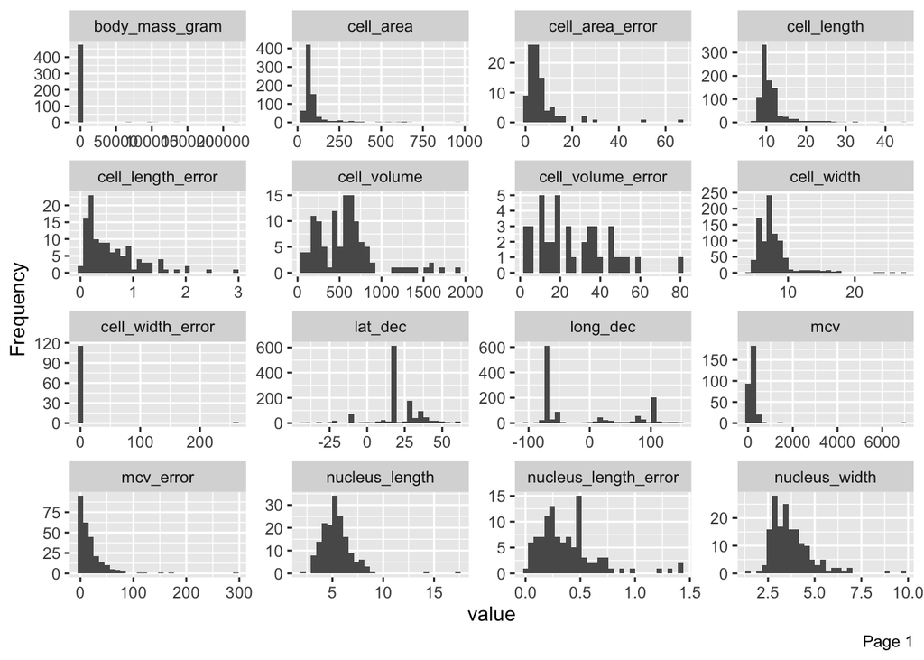

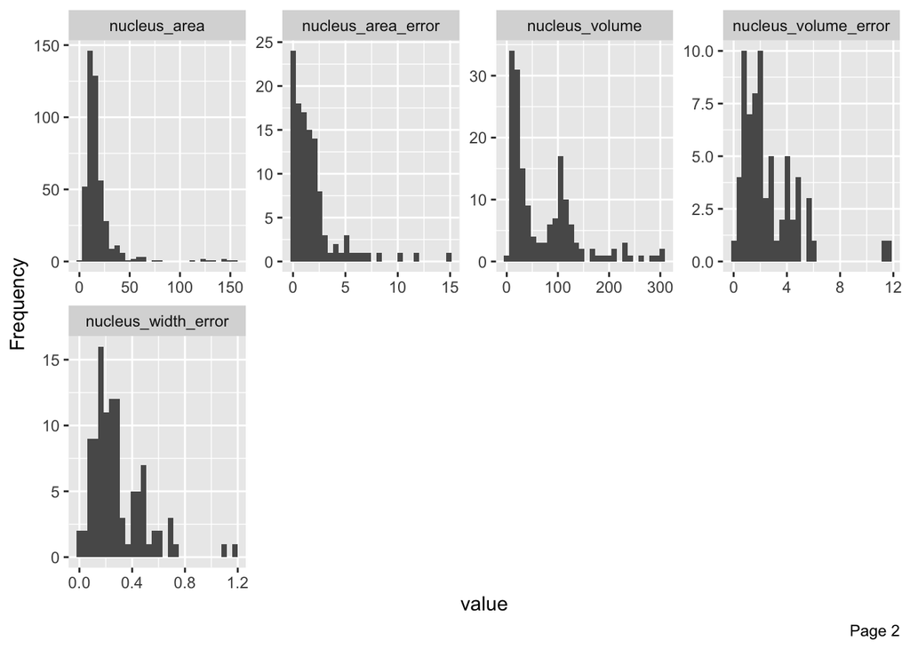

```r
plot_histogram(dat)
```

I conducted an analysis for each cell size trait. By examining frequency distribution histograms, I established distribution thresholds for these variables. These thresholds were set somewhat arbitrarily for each trait but allowed for manual inspection of any values below or above them. In cases where an error was detected, I referred back to the original source and rechecked the data thoroughly.

## Check data of cell area via histogram

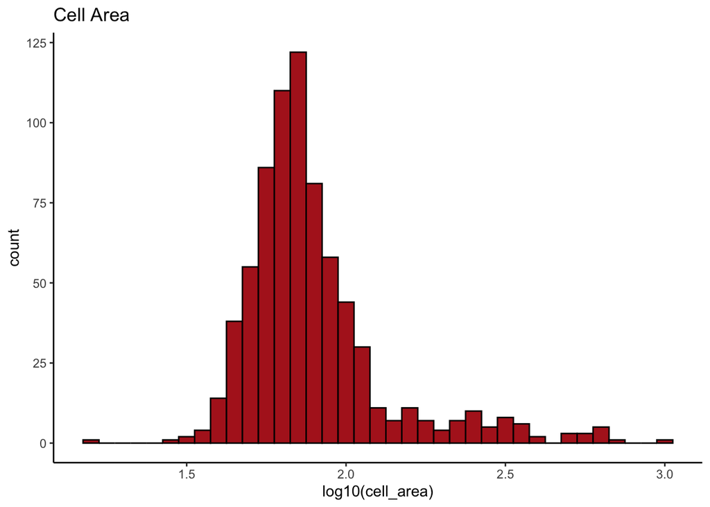

```r
dat %>%
  filter(is.finite(cell_area)) %>%
  ggplot(aes(log10(cell_area))) +
  geom_histogram(fill = "firebrick", col = "black", binwidth = 0.05) +
  theme_classic() +
  labs(title = "Cell Area")
```

```r
dat %>%
  filter(is.finite(cell_area)) %>%
  mutate(log10_cell_area = log10(cell_area)) %>%  # Calculate log10(cell_area)
  filter(log10_cell_area < 1.3 | log10_cell_area > 2.9) %>%  # Apply thresholds, based on data distribution
  select(key, class, species_reported, log10_cell_area, cell_area) %>%  # Select relevant columns
  arrange(key, cell_area)
```

```
##                           key          class                species_reported
## 1 pdf_not_found_Gulliver_1875         Dipnoi Protopterus annectens annectens
## 2             rayyan-33186293 Actinopterygii         Iranocichla hormuzensis
##   log10_cell_area cell_area
## 1        2.975294    944.70
## 2        1.210051     16.22
```

## Check data of cell volume via histogram

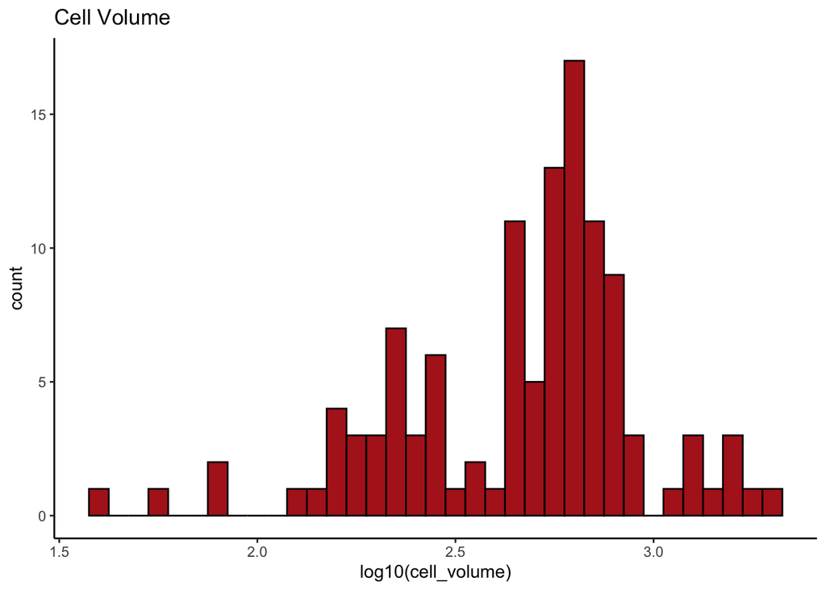

```r
ggplot(dat %>% filter(is.finite(cell_volume)), aes(log10(cell_volume))) +
  geom_histogram(fill = "firebrick", color = "black", binwidth = 0.05) +
  theme_classic() +
  labs(title = "Cell Volume")
```

```r
dat %>%
  filter(is.finite(cell_volume)) %>%
  mutate(log10_cell_volume = log10(cell_volume)) %>%  # Calculate log10(cell_volume)
  filter(log10_cell_volume < 2 | log10_cell_volume > 3) %>%  # Apply thresholds, based on data distribution
  select(key, class, species_reported, log10_cell_volume, cell_volume) %>%  # Select relevant columns
  arrange(key, cell_volume)
```

```
##                key          class           species_reported log10_cell_volume
## 1  rayyan-33185780 Actinopterygii      Pygocentrus nattereri          3.066334
## 2  rayyan-33185780 Actinopterygii      Pygocentrus nattereri          3.080239
## 3  rayyan-33185780 Actinopterygii      Pygocentrus nattereri          3.106438
## 4  rayyan-33185780 Actinopterygii      Pygocentrus nattereri          3.116222
## 5  rayyan-33185780 Actinopterygii     Synbranchus marmoratus          3.139796
## 6  rayyan-33185780 Actinopterygii      Pygocentrus nattereri          3.191964
## 7  rayyan-33185780 Actinopterygii     Synbranchus marmoratus          3.196839
## 8  rayyan-33185780 Actinopterygii     Synbranchus marmoratus          3.201626
## 9  rayyan-33185780 Actinopterygii     Synbranchus marmoratus          3.236037
## 10 rayyan-33185780 Actinopterygii     Synbranchus marmoratus          3.276326
## 11 rayyan-33185803 Actinopterygii          Crenilabrus tinca          1.738781
## 12 rayyan-33185803 Actinopterygii         Uranoscopus scaber          1.903090
## 13 rayyan-33185803 Actinopterygii Gaidropsarus mediterraneus          1.920645
## 14 rayyan-33186293 Actinopterygii    Iranocichla hormuzensis          1.613630
##    cell_volume
## 1     1165.023
## 2     1202.926
## 3     1277.725
## 4     1306.839
## 5     1379.736
## 6     1555.835
## 7     1573.400
## 8     1590.838
## 9     1722.017
## 10    1889.407
## 11      54.800
## 12      80.000
## 13      83.300
## 14      41.080
```

## Check data of nucleus area via histogram

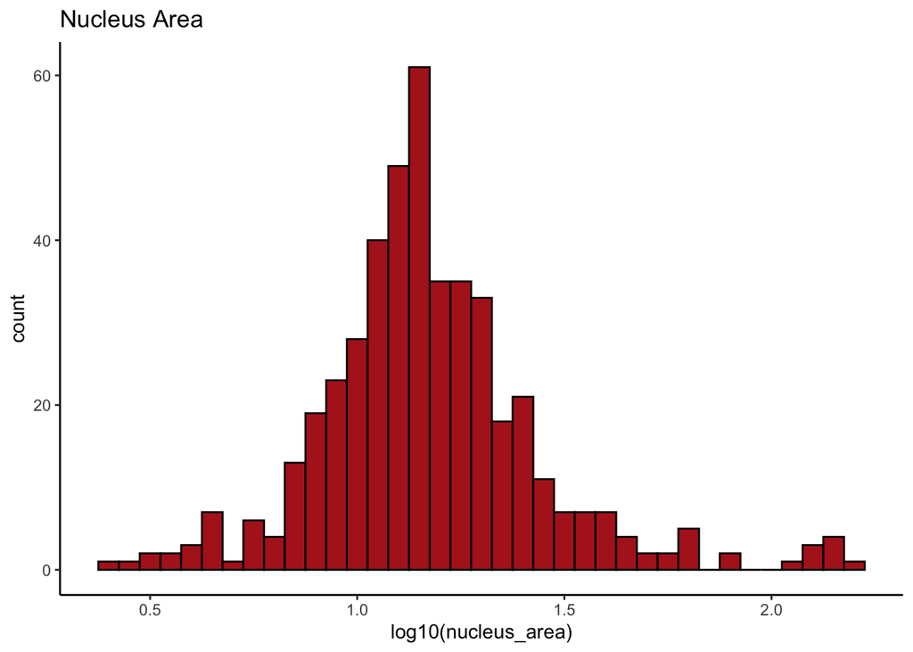

```r
dat %>%
  filter(is.finite(nucleus_area)) %>%
  ggplot(aes(log10(nucleus_area))) +
  geom_histogram(fill = "firebrick", col = "black", binwidth = 0.05) +
  theme_classic() +
  labs(title = "Nucleus Area")
```

```r
dat %>%
  filter(is.finite(nucleus_area)) %>%
  mutate(log10_nucleus_area = log10(nucleus_area)) %>%  # Calculate log10(nucleus_area)
  filter(log10_nucleus_area < 0.6 | log10_nucleus_area > 2) %>%  # Apply thresholds, based on data distribution
  select(key, class, species_reported, log10_nucleus_area, nucleus_area) %>%  # Select relevant columns
  arrange(key, nucleus_area)
```

```
##                            key          class                species_reported
## 1                    9_gregory Chondrichthyes             Oxynotus bruniensis
## 2                    9_gregory Chondrichthyes           Centroscymnus owstoni
## 3                    9_gregory Chondrichthyes        Centroscymnus coelolepis
## 4                    9_gregory Chondrichthyes           Etmopterus granulosus
## 5                    9_gregory Chondrichthyes              Squatina australis
## 6                    9_gregory Chondrichthyes           Etmopterus brachyurus
## 7                    9_gregory Chondrichthyes        Centroscymnus crepidater
## 8                    9_gregory Chondrichthyes          Centroscymnus plunketi
## 9  pdf_not_found_Gulliver_1875         Dipnoi Protopterus annectens annectens
## 10             rayyan-33186100 Actinopterygii               Upeneus maculatus
## 11             rayyan-33186100 Actinopterygii              Balistes capriscus
## 12             rayyan-33186100 Actinopterygii         Bathystoma aurilineatum
## 13             rayyan-33186100 Actinopterygii                 Calamus calamus
## 14             rayyan-33186211 Actinopterygii              Micropterus coosae
```

[output cut: 19 more lines]

## Check data of nucleus volume via histogram

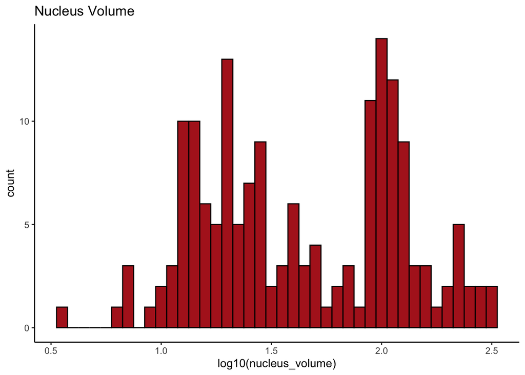

```r
dat %>%
  filter(is.finite(nucleus_volume)) %>%
  ggplot(aes(log10(nucleus_volume))) +
  geom_histogram(fill = "firebrick", col = "black", binwidth = 0.05) +
  theme_classic() +
  labs(title = "Nucleus Volume")
```

```r
dat %>%
  filter(is.finite(nucleus_volume)) %>%
  mutate(log10_nucleus_volume = log10(nucleus_volume)) %>%  # Calculate log10(nucleus_volume)
  filter(log10_nucleus_volume < 0.8 | log10_nucleus_volume > 2.5) %>%  # Apply thresholds, based on data distribution (p2)
  select(key, class, species_reported, log10_nucleus_volume, nucleus_volume) %>%  # Select relevant columns
  arrange(key, nucleus_volume)
```

```
##               key          class        species_reported log10_nucleus_volume
## 1 rayyan-33186293 Actinopterygii Iranocichla hormuzensis            0.5340261
##   nucleus_volume
## 1           3.42
```

## Check data of cell length via histogram

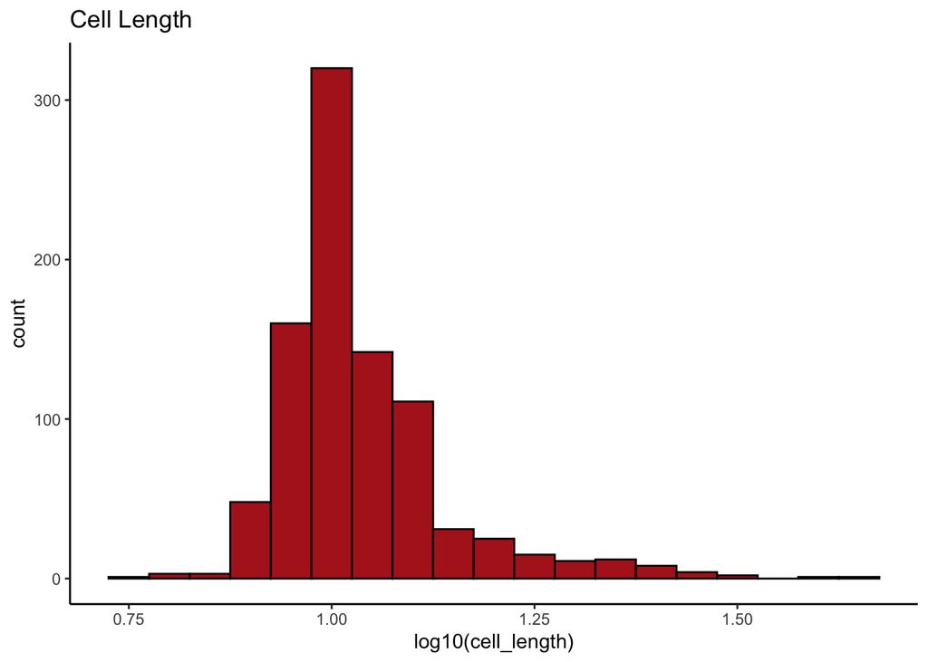

```r
dat %>%
  filter(is.finite(cell_length)) %>%
  ggplot(aes(log10(cell_length))) +
  geom_histogram(fill = "firebrick", col = "black", binwidth = 0.05) +
  theme_classic() +
  labs(title = "Cell Length")
```

```r
dat %>%
  filter(is.finite(cell_length)) %>%
  mutate(log10_cell_length = log10(cell_length)) %>%  # Calculate log10(cell_length)
  filter(log10_cell_length < 0.8 | log10_cell_length > 1.5) %>%  # Apply thresholds, based on data distribution
  select(key, location_description, class, species_reported, log10_cell_length, cell_length) %>%  # Select relevant columns
  arrange(key,location_description, cell_length)
```

```
##                           key                        location_description
## 1                   3_gregory                                        <NA>
## 2 pdf_not_found_Gulliver_1875                                        <NA>
## 3 pdf_not_found_Gulliver_1875                                        <NA>
## 4 pdf_not_found_Gulliver_1875                                        <NA>
## 5             rayyan-33186293                          Mehran river, Iran
## 6             rayyan-33186496     Libong Island, Trang Province, Thailand
## 7             rayyan-33186496 Rajamangala Beach, Trang Province, Thailand
##            class                species_reported log10_cell_length cell_length
## 1         Dipnoi              Ceratodus forsteri         1.5910646       39.00
## 2 Chondrichthyes               Oxynotus centrina         1.5024271       31.80
## 3 Chondrichthyes                 Torpedo torpedo         1.5024271       31.80
## 4         Dipnoi Protopterus annectens annectens         1.6493349       44.60
## 5 Actinopterygii         Iranocichla hormuzensis         0.7411516        5.51
## 6 Actinopterygii             Gerres filamentosus         0.7888751        6.15
## 7 Actinopterygii             Leiognathus decorus         0.7972675        6.27
```

## Check data of cell width via histogram

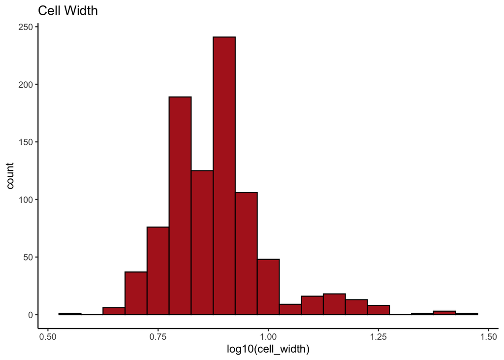

```r
dat %>%
  filter(is.finite(cell_width)) %>%
  ggplot(aes(log10(cell_width))) +
  geom_histogram(fill = "firebrick", col = "black", binwidth = 0.05) +
  theme_classic() +
  labs(title = "Cell Width")
```

```r
dat %>%
  filter(is.finite(cell_width)) %>%
  mutate(log10_cell_width = log10(cell_width)) %>%  # Calculate log10(cell_width)
  filter(log10_cell_width < 0.6 | log10_cell_width > 1.3) %>%  # Apply thresholds, based on data distribution
  select(key, class, species_reported, log10_cell_width, cell_width) %>%  # Select relevant columns
  arrange(key, cell_width)
```

```
##                           key          class                species_reported
## 1                   3_gregory         Dipnoi              Ceratodus forsteri
## 2 pdf_not_found_Gulliver_1875 Chondrichthyes               Oxynotus centrina
## 3 pdf_not_found_Gulliver_1875 Chondrichthyes                 Torpedo torpedo
## 4 pdf_not_found_Gulliver_1875         Dipnoi Protopterus annectens annectens
## 5    pdf_not_found_Kisch_1951 Chondrichthyes               Torpedo nobiliana
## 6             rayyan-33186293 Actinopterygii         Iranocichla hormuzensis
##   log10_cell_width cell_width
## 1        1.3802112      24.00
## 2        1.4048337      25.40
## 3        1.4048337      25.40
## 4        1.4313638      27.00
## 5        1.3654880      23.20
## 6        0.5728716       3.74
```

## Check data of nucleus length via histogram

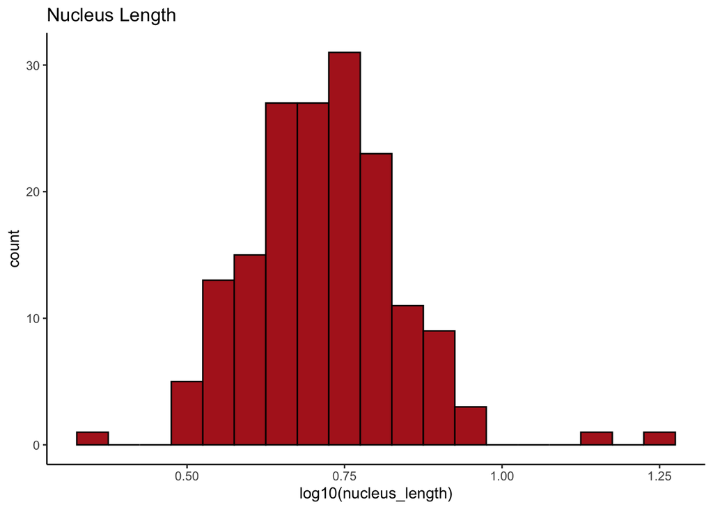

```r
dat %>%
  filter(is.finite(nucleus_length)) %>%
  ggplot(aes(log10(nucleus_length))) +
  geom_histogram(fill = "firebrick", col = "black", binwidth = 0.05) +
  theme_classic() +
  labs(title = "Nucleus Length")
```

```r
dat %>%
  filter(is.finite(nucleus_length)) %>%
  mutate(log10_nucleus_length = log10(nucleus_length)) %>%  # Calculate log10(nucleus_length)
  filter(log10_nucleus_length < 0.5 | log10_nucleus_length > 1) %>%  # Apply thresholds, based on data distribution
  select(key, class, species_reported, log10_nucleus_length, nucleus_length) %>%  # Select relevant columns
  arrange(key, nucleus_length)
```

```
##                           key          class                species_reported
## 1                   3_gregory         Dipnoi              Ceratodus forsteri
## 2 pdf_not_found_Gulliver_1875         Dipnoi Protopterus annectens annectens
## 3             rayyan-33186293 Actinopterygii         Iranocichla hormuzensis
## 4             rayyan-33186496 Actinopterygii             Leiognathus decorus
##   log10_nucleus_length nucleus_length
## 1            1.1461280          14.00
## 2            1.2430380          17.50
## 3            0.3502480           2.24
## 4            0.4955443           3.13
```

## Check data of nucleus width via histogram

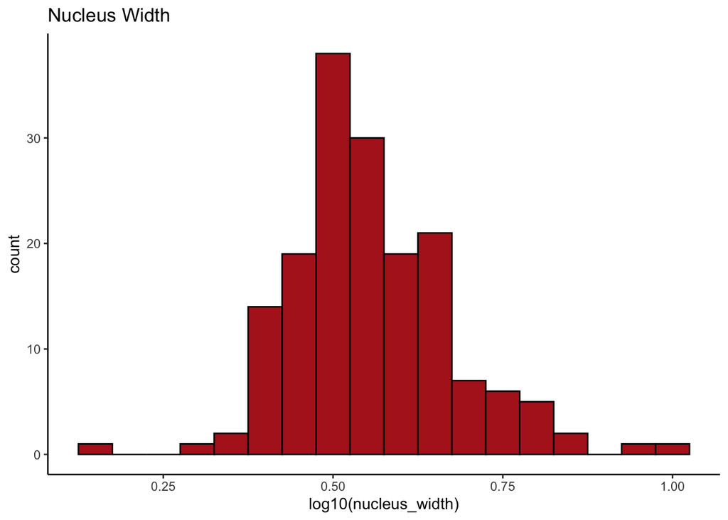

```r
dat %>%
  filter(is.finite(nucleus_width)) %>%
  ggplot(aes(log10(nucleus_width))) +
  geom_histogram(fill = "firebrick", col = "black", binwidth = 0.05) +
  theme_classic() +
  labs(title = "Nucleus Width")
```

```r
dat %>%
  filter(is.finite(nucleus_width)) %>%
  mutate(log10_nucleus_width = log10(nucleus_width)) %>%  # Calculate log10(nucleus_width)
  filter(log10_nucleus_width < 0.25 | log10_nucleus_width > 0.85) %>%  # Apply thresholds, based on data distribution
  select(key, class, species_reported, log10_nucleus_width, nucleus_width) %>%  # Select relevant columns
  arrange(key, nucleus_width)
```

```
##                           key          class                species_reported
## 1                   3_gregory         Dipnoi              Ceratodus forsteri
## 2 pdf_not_found_Gulliver_1875         Dipnoi Protopterus annectens annectens
## 3             rayyan-33186293 Actinopterygii         Iranocichla hormuzensis
##   log10_nucleus_width nucleus_width
## 1           0.9890046          9.75
## 2           0.9444827          8.80
## 3           0.1583625          1.44
```

## Check data of Mean Corpuscular Volume (MCV) via histogram

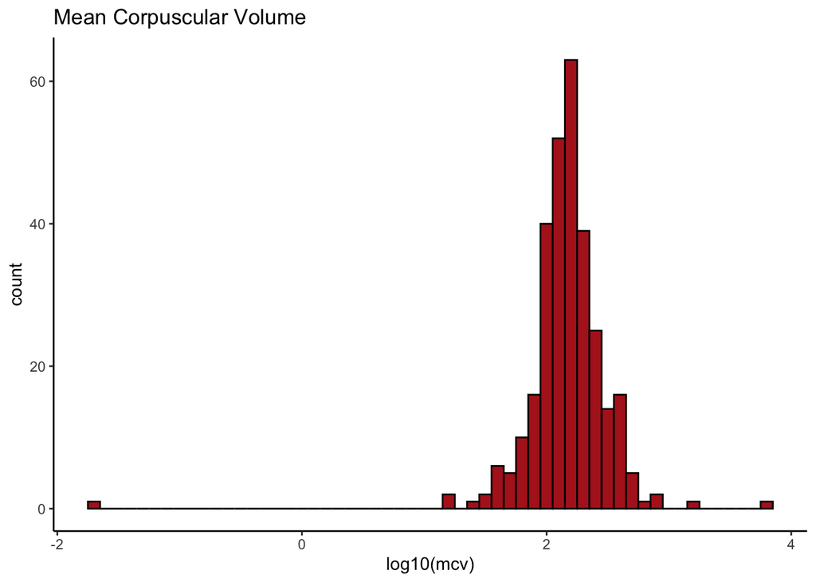

```r
dat %>%
  filter(is.finite(mcv)) %>%
  ggplot(aes(log10(mcv))) +
  geom_histogram(fill = "firebrick", col = "black", binwidth = 0.1) +
  theme_classic() +
  labs(title = "Mean Corpuscular Volume")
```

```r
dat %>%
  filter(is.finite(mcv)) %>%
  mutate(log10_mcv = log10(mcv)) %>%  # Calculate log10(mcv)
  filter(log10_mcv < 1 | log10_mcv > 3) %>%  # Apply thresholds, based on data distribution
  select(key, class, species_reported, log10_mcv, mcv) %>%  # Select relevant columns
  arrange(key, mcv)
```

```
##               key          class        species_reported log10_mcv        mcv
## 1 rayyan-33186305         Dipnoi Protopterus aethiopicus  3.841359 6940.00000
## 2 rayyan-33186404 Actinopterygii     Heterotis niloticus -1.718512    0.01912
## 3 rayyan-33189616 Chondrichthyes   Scyliorhinus canicula  3.186872 1537.70000
```

For a particular study (rayyan-33186404), I observed that the decimal notation (full stops versus commas) was inconsistent. Consequently, I decided to calculate the MCV based on the haematocrit and erythrocyte count values using the formula described in the main text of our manuscript. Employing this formula yielded an approximate value of 187.1622 μm³. I also replaced the error of MCV by NA.

```r
dat <- dat %>%
  mutate(
    mcv = ifelse(species_reported == "Heterotis niloticus" & key == "rayyan-33186404", 187.1622, mcv),
    mcv_error = ifelse(species_reported == "Heterotis niloticus" & key == "rayyan-33186404", NA, mcv_error)
  )
```

```r
dat %>%
  filter(species_reported == "Heterotis niloticus") %>%
  select(key, species_reported,body_mass_gram, mcv, mcv_error)
```

```
##               key    species_reported body_mass_gram      mcv mcv_error
## 1 rayyan-33186379 Heterotis niloticus          429.4 191.2000     13.74
## 2 rayyan-33186404 Heterotis niloticus          429.4 187.1622        NA
```

As a result of this, the study containing the error was excluded from the database. In Figure 1, this study will be labelled under “RBC expressed in wrong units”.

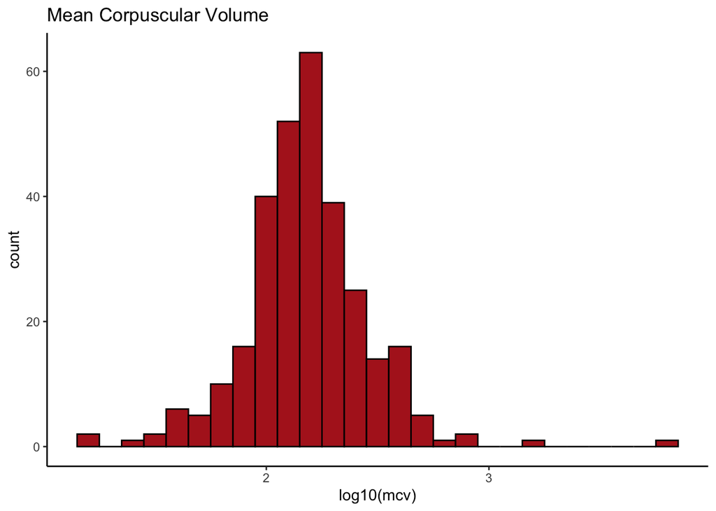

```r
# Lets exclude that study
dat <- dat  %>%
  filter(key != "rayyan-33186404")

# Lets check again the data on MCV
dat %>%
  filter(is.finite(mcv)) %>%
  ggplot(aes(log10(mcv))) +
  geom_histogram(fill = "firebrick", col = "black", binwidth = 0.1) +
  theme_classic() +
  labs(title = "Mean Corpuscular Volume")
```

```r
dat %>%
  filter(is.finite(mcv)) %>%
  mutate(log10_mcv = log10(mcv)) %>%  # Calculate log10(mcv)
  filter(log10_mcv < 1.2 | log10_mcv > 3) %>%  # Apply thresholds, based on data distribution
  select(key, class, species_reported, log10_mcv, mcv) %>%  # Select relevant columns
  arrange(key, mcv)
```

```
##               key          class        species_reported log10_mcv     mcv
## 1 rayyan-33186305         Dipnoi Protopterus aethiopicus  3.841359 6940.00
## 2 rayyan-33189616 Chondrichthyes   Scyliorhinus canicula  3.186872 1537.70
## 3 rayyan-33189628 Actinopterygii      Solea senegalensis  1.158061   14.39
## 4 rayyan-33189628 Actinopterygii      Solea senegalensis  1.167317   14.70
```

# Calculation of Cell and Nuclear Dimensions

I also calculate the cell area, cell volume, nuclear area, and nuclear volume using available length and width data. This approach allows us to derive these parameters when direct measurements are unavailable, thereby enhancing the completeness of ErythroCite.

For this, I employed standard formulae to calculate the area and the volume of the cell or its nucleus, assuming that both the cell and its nucleus were shaped like ellipsoids or oblate spheroids (Benfey & Sutterlin, 1984; Gregory, 2024).

The formula for cellular area (A) is:

$$A = \pi \times \frac{a}{2} \times \frac{b}{2}$$

```r
# Calculate cell area and volume if missing
dat$cell_area <- ifelse(is.na(dat$cell_area),
                                   pi * (dat$cell_length/2) * (dat$cell_width/2),
                                   dat$cell_area)

dat$cell_volume <- ifelse(is.na(dat$cell_volume),
                                     (4/3) * pi * (dat$cell_length/2) * (dat$cell_width/2)^2,
                                     dat$cell_volume)
```

The formula for cellular volume (V) is:

$$V = \frac{4}{3} \times \pi \times \frac{a}{2} \times \left(\frac{b}{2}\right)^2$$

```r
# Calculate nuclear area and volume if missing
dat$nucleus_area <- ifelse(is.na(dat$nucleus_area),
                                      pi * (dat$nucleus_length/2) * (dat$nucleus_width/2),
                                      dat$nucleus_area)

dat$nucleus_volume <- ifelse(is.na(dat$nucleus_volume),
                                        (4/3) * pi * (dat$nucleus_length/2) * (dat$nucleus_width/2)^2,
                                        dat$nucleus_volume)
```

# Transformation of all errors to SDs, when is possible.

I will apply transformations to the error columns (`cell_length_error`, `cell_width_error`, `cell_area_error`, `cell_volume_error`, `mcv_error`, `nucleus_length_error`, `nucleus_width_error`, `nucleus_area_error`, and `nucleus_volume_error`) based on the `estimate_error_type` column:

```r
unique(dat$estimate_error_type)
```

```
## [1] NA      "2SE"   "SD"    "SE"    "95_CI"
```

For these type of errors, the transformations are based on well-known fomuelae :

1. **SD (Standard Deviation)**: The value remains unchanged if the error type is “SD”.
2. **SE (Standard Error)**: The error is converted to SD using the formula:

$$\text{SD} = \text{SE} \times \sqrt{N}$$

where $N$ is the number of specimens used for the trait mean estimate.

3. **2SE (Twice the Standard Error)**: The error is converted to SD using the formula:

$$\text{SD} = \left(\frac{\text{2SE}}{2}\right) \times \sqrt{N} = \text{SE} \times \sqrt{N}$$

where $N$ is the number of specimens used for the trait mean estimate.

4. **95% CI (95% Confidence Interval)**: The error is converted to SD using the formula:

$$\text{SD} = \left(\frac{\text{95% CI}}{1.96}\right) \times \sqrt{N}$$

where $n$ is the number of specimens, and $1.96$ corresponds to the Z-score for a 95% confidence interval.

```r
# transform 'number_of_specimens' to numeric
dat$number_of_specimens <- as.numeric(as.character(dat$number_of_specimens))

# Apply transformation to all relevant error columns

dat <- dat %>%
  mutate(

    # Transforming cell_length_error to SD

    cell_length_sd = case_when(
      estimate_error_type == "SD" ~ cell_length_error,  # Keep SD values unchanged
      estimate_error_type == "SE" & !is.na(number_of_specimens) & number_of_specimens > 1 ~ cell_length_error * sqrt(number_of_specimens),  # Convert SE to SD
      estimate_error_type == "2SE" & !is.na(number_of_specimens) & number_of_specimens > 1 ~ (cell_length_error / 2) * sqrt(number_of_specimens),  # Convert 2SE to SD
      estimate_error_type == "95_CI" & !is.na(number_of_specimens) & number_of_specimens > 1 ~ (cell_length_error / 1.96) * sqrt(number_of_specimens),  # Convert 95% CI to SD
      TRUE ~ NA_real_  # Assign NA if conversion is not possible
    ),
    # Transforming cell_width_error to SD
    cell_width_sd = case_when(
      estimate_error_type == "SD" ~ cell_width_error,  # Keep SD values unchanged
      estimate_error_type == "SE" & !is.na(number_of_specimens) & number_of_specimens > 1 ~ cell_width_error * sqrt(number_of_specimens),  # Convert SE to SD
      estimate_error_type == "2SE" & !is.na(number_of_specimens) & number_of_specimens > 1 ~ (cell_width_error / 2) * sqrt(number_of_specimens),  # Convert 2SE to SD
      estimate_error_type == "95_CI" & !is.na(number_of_specimens) & number_of_specimens > 1 ~ (cell_width_error / 1.96) * sqrt(number_of_specimens),  # Convert 95% CI to SD
      TRUE ~ NA_real_  # Assign NA if conversion is not possible
    ),

    # Transforming cell_area_error to SD

    cell_area_sd = case_when(
      estimate_error_type == "SD" ~ cell_area_error,  # Keep SD values unchanged
      estimate_error_type == "SE" & !is.na(number_of_specimens) & number_of_specimens > 1 ~ cell_area_error * sqrt(number_of_specimens),  # Convert SE to SD
      estimate_error_type == "2SE" & !is.na(number_of_specimens) & number_of_specimens > 1 ~ (cell_area_error / 2) * sqrt(number_of_specimens),  # Convert 2SE to SD
      estimate_error_type == "95_CI" & !is.na(number_of_specimens) & number_of_specimens > 1 ~ (cell_area_error / 1.96) * sqrt(number_of_specimens),  # Convert 95% CI to SD
      TRUE ~ NA_real_  # Assign NA if conversion is not possible
    ),

    # Transforming cell_volume_error to SD

    cell_volume_sd = case_when(
      estimate_error_type == "SD" ~ cell_volume_error,  # Keep SD values unchanged
      estimate_error_type == "SE" & !is.na(number_of_specimens) & number_of_specimens > 1 ~ cell_volume_error * sqrt(number_of_specimens),  # Convert SE to SD
      estimate_error_type == "2SE" & !is.na(number_of_specimens) & number_of_specimens > 1 ~ (cell_volume_error / 2) * sqrt(number_of_specimens),  # Convert 2SE to SD
      estimate_error_type == "95_CI" & !is.na(number_of_specimens) & number_of_specimens > 1 ~ (cell_volume_error / 1.96) * sqrt(number_of_specimens),  # Convert 95% CI to SD
      TRUE ~ NA_real_  # Assign NA if conversion is not possible
    ),

    # Transforming mcv_error to SD

    mcv_sd = case_when(
      estimate_error_type == "SD" ~ mcv_error,  # Keep SD values unchanged
      estimate_error_type == "SE" & !is.na(number_of_specimens) & number_of_specimens > 1 ~ mcv_error * sqrt(number_of_specimens),  # Convert SE to SD
      estimate_error_type == "2SE" & !is.na(number_of_specimens) & number_of_specimens > 1 ~ (mcv_error / 2) * sqrt(number_of_specimens),  # Convert 2SE to SD
      estimate_error_type == "95_CI" & !is.na(number_of_specimens) & number_of_specimens > 1 ~ (mcv_error / 1.96) * sqrt(number_of_specimens),  # Convert 95% CI to SD
      TRUE ~ NA_real_  # Assign NA if conversion is not possible
    ),

    # Transforming nucleus_length_error to SD

    nucleus_length_sd = case_when(
      estimate_error_type == "SD" ~ nucleus_length_error,  # Keep SD values unchanged
      estimate_error_type == "SE" & !is.na(number_of_specimens) & number_of_specimens > 1 ~ nucleus_length_error * sqrt(number_of_specimens),  # Convert SE to SD
      estimate_error_type == "2SE" & !is.na(number_of_specimens) & number_of_specimens > 1 ~ (nucleus_length_error / 2) * sqrt(number_of_specimens),  # Convert 2SE to SD
      estimate_error_type == "95_CI" & !is.na(number_of_specimens) & number_of_specimens > 1 ~ (nucleus_length_error / 1.96) * sqrt(number_of_specimens),  # Convert 95% CI to SD
      TRUE ~ NA_real_  # Assign NA if conversion is not possible
    ),

    # Transforming nucleus_width_error to SD

    nucleus_width_sd = case_when(
      estimate_error_type == "SD" ~ nucleus_width_error,  # Keep SD values unchanged
      estimate_error_type == "SE" & !is.na(number_of_specimens) & number_of_specimens > 1 ~ nucleus_width_error * sqrt(number_of_specimens),  # Convert SE to SD
      estimate_error_type == "2SE" & !is.na(number_of_specimens) & number_of_specimens > 1 ~ (nucleus_width_error / 2) * sqrt(number_of_specimens),  # Convert 2SE to SD
      estimate_error_type == "95_CI" & !is.na(number_of_specimens) & number_of_specimens > 1 ~ (nucleus_width_error / 1.96) * sqrt(number_of_specimens),  # Convert 95% CI to SD
      TRUE ~ NA_real_  # Assign NA if conversion is not possible
    ),

    # Transforming nucleus_area_error to SD

    nucleus_area_sd = case_when(
      estimate_error_type == "SD" ~ nucleus_area_error,  # Keep SD values unchanged
      estimate_error_type == "SE" & !is.na(number_of_specimens) & number_of_specimens > 1 ~ nucleus_area_error * sqrt(number_of_specimens),  # Convert SE to SD
      estimate_error_type == "2SE" & !is.na(number_of_specimens) & number_of_specimens > 1 ~ (nucleus_area_error / 2) * sqrt(number_of_specimens),  # Convert 2SE to SD
      estimate_error_type == "95_CI" & !is.na(number_of_specimens) & number_of_specimens > 1 ~ (nucleus_area_error / 1.96) * sqrt(number_of_specimens),  # Convert 95% CI to SD
      TRUE ~ NA_real_  # Assign NA if conversion is not possible
    ),

    # Transforming nucleus_volume_error to SD

    nucleus_volume_sd = case_when(
      estimate_error_type == "SD" ~ nucleus_volume_error,  # Keep SD values unchanged
      estimate_error_type == "SE" & !is.na(number_of_specimens) & number_of_specimens > 1 ~ nucleus_volume_error * sqrt(number_of_specimens),  # Convert SE to SD
      estimate_error_type == "2SE" & !is.na(number_of_specimens) & number_of_specimens > 1 ~ (nucleus_volume_error / 2) * sqrt(number_of_specimens),  # Convert 2SE to SD
      estimate_error_type == "95_CI" & !is.na(number_of_specimens) & number_of_specimens > 1 ~ (nucleus_volume_error / 1.96) * sqrt(number_of_specimens),  # Convert 95% CI to SD
      TRUE ~ NA_real_  # Assign NA if conversion is not possible
    )
  )
```

# Extract names of countries using the geographical coordinates

```r
# lines below take some time to run
dat <- dat %>%
  reverse_geocode(lat = lat_dec,
                                long = long_dec,
                                method = "osm") %>%
  mutate(country_collection = sub(".*,\\s*", "", address))  # Extract country name
```

# Rename countries using names in English and create a column to assign sub-continent.

Many of the country names are in their native languages; therefore, I changed all the names to their official English versions.

```r
dat <- dat %>%
  mutate(country_collection = case_when(
    country_collection == "Bermuda" ~ "United Kingdom",
    country_collection == "Bosna i Hercegovina / Босна и Херцеговина" ~ "Bosnia and Herzegovina",
    country_collection == "Brasil" ~ "Brazil",
    country_collection == "Česko" ~ "Czechia",
    country_collection == "Congo" ~ "Democratic Republic of the Congo",
    country_collection == "Deutschland" ~ "Germany",
    country_collection == "España" ~ "Spain",
    country_collection == "Italia" ~ "Italy",
    country_collection == "Mauritius / Maurice" ~ "Mauritius",
    country_collection == "México" ~ "Mexico",
    country_collection == "Perú" ~ "Peru",
    country_collection == "Norge" ~ "Norway",
    country_collection == "Polska" ~ "Poland",
    country_collection == "Türkiye" ~ "Turkey",
    country_collection == "Sverige" ~ "Sweden",
    country_collection == "United States" ~ "United States of America",
    country_collection == "Ελλάς" ~ "Greece",
    country_collection == "Россия" ~ "Russia",
    country_collection == "Україна" ~ "Ukraine",
    country_collection == "العراق" ~ "Iraq",
    country_collection == "پاکستان" ~ "Pakistan",
    country_collection == "ایران" ~ "Iran",
    country_collection == "سوريا" ~ "Syria",
    country_collection == "مصر" ~ "Egypt",
    country_collection == "عمان" ~ "Oman",
    country_collection == "ประเทศไทย" ~ "Thailand",
    country_collection == "বাংলাদেশ" ~ "Bangladesh",
    country_collection == "대한민국" ~ "South Korea",
    country_collection == "中国" ~ "China",
    country_collection == "日本" ~ "Japan",
    TRUE ~ country_collection
  )) %>%
  mutate(subcontinent = case_when(
    country_collection %in% c("Argentina", "Brazil", "Chile", "Colombia", "Ecuador", "Peru", "Venezuela") ~ "South America",  # South America
    country_collection %in% c("United States of America", "Mexico", "Bermuda") ~ "North America",  # North America
    country_collection %in% c("United Kingdom", "Germany", "France", "Italy", "Spain", "Portugal", "Norway", "Sweden") ~ "Western Europe",  # Western Europe
    country_collection %in% c("Russia", "Ukraine", "Poland", "Czechia", "Greece", "Bosnia and Herzegovina") ~ "Eastern Europe",  # Eastern Europe
    country_collection %in% c("Iran", "Iraq", "Turkey", "Oman", "Syria") ~ "Middle East",  # Middle East
    country_collection %in% c("India", "Pakistan", "Bangladesh") ~ "South Asia",  # South Asia
    country_collection %in% c("China", "Japan", "South Korea") ~ "East Asia",  # East Asia
    country_collection %in% c("Malaysia", "Thailand") ~ "Southeast Asia",  # Southeast Asia
    country_collection %in% c("Egypt", "Nigeria", "Mauritius", "Niger", "Democratic Republic of the Congo") ~ "Africa",  # Africa
    country_collection %in% c("Australia") ~ "Oceania",  # Oceania
    TRUE ~ country_collection  # Default for unclassified countries
  ))
```

```r
# check again
unique(dat$country_collection)
```

```
##  [1] NA                                 "United Kingdom"
##  [3] "United States of America"         "India"
##  [5] "China"                            "Brazil"
##  [7] "Mexico"                           "Czechia"
##  [9] "Venezuela"                        "Japan"
## [11] "Chile"                            "Iran"
## [13] "Turkey"                           "Ukraine"
## [15] "Pakistan"                         "Nigeria"
## [17] "Egypt"                            "Russia"
## [19] "Argentina"                        "Australia"
## [21] "Poland"                           "Iraq"
## [23] "Democratic Republic of the Congo" "Bosnia and Herzegovina"
## [25] "Greece"                           "Italy"
## [27] "Ecuador"                          "Mauritius"
## [29] "Thailand"                         "Syria"
## [31] "Malaysia"                         "Bangladesh"
## [33] "South Korea"                      "Peru"
## [35] "Niger"                            "Colombia"
## [37] "Sweden"                           "Norway"
## [39] "Germany"                          "Spain"
## [41] "Portugal"                         "Oman"
```

```r
# select relevant columns
dat_cleaned <- dat %>%
  select(-double_checked, -source, taxo_level, -isMarine, -isBrackish, -isFresh, -address)

# reorder columns
names(dat_cleaned)
```

```
##  [1] "species_reported"     "database"             "key"
##  [4] "body_mass_gram"       "sex"                  "life_stage"
##  [7] "lat_dec"              "long_dec"             "location_description"
## [10] "sample_size"          "number_of_specimens"  "estimate_error_type"
## [13] "cell_length"          "cell_length_error"    "cell_width"
## [16] "cell_width_error"     "cell_area"            "cell_area_error"
## [19] "cell_volume"          "cell_volume_error"    "mcv"
## [22] "mcv_error"            "nucleus_length"       "nucleus_length_error"
## [25] "nucleus_width"        "nucleus_width_error"  "nucleus_area"
## [28] "nucleus_area_error"   "nucleus_volume"       "nucleus_volume_error"
## [31] "notes"                "phylum"               "class"
## [34] "order"                "family"               "genus"
## [37] "species"              "taxo_level"           "realm"
## [40] "species_underscored"  "cell_length_sd"       "cell_width_sd"
## [43] "cell_area_sd"         "cell_volume_sd"       "mcv_sd"
## [46] "nucleus_length_sd"    "nucleus_width_sd"     "nucleus_area_sd"
## [49] "nucleus_volume_sd"    "country_collection"   "subcontinent"
```

```r
dat_cleaned <- dat_cleaned %>%
  select(database, key, phylum, class, order, family, genus, species,species_reported, species_underscored,taxo_level,
         realm,
         lat_dec, long_dec, location_description, country_collection, subcontinent,
         everything()) %>%
  mutate(across(where(is.numeric), ~round(., digits = 4)))
```